# Data Preprocessing with pandas.

# Numerical Variables

1. Age
2. SibSp
3. Parch
4. Fare

```python
df['Age']
```

```
PassengerId
1      22.0
2      38.0
3      26.0
4      35.0
5      35.0
6       NaN
7      54.0
8       2.0
9      27.0
10     14.0
11      4.0
12     58.0
13     20.0
14     39.0
```

[output cut: 48 more lines]

```python
# It does not make sense to use unique
df['Age'].unique()
```

```
array([22.  , 38.  , 26.  , 35.  ,   nan, 54.  ,  2.  , 27.  , 14.  ,
        4.  , 58.  , 20.  , 39.  , 55.  , 31.  , 34.  , 15.  , 28.  ,
        8.  , 19.  , 40.  , 66.  , 42.  , 21.  , 18.  ,  3.  ,  7.  ,
       49.  , 29.  , 65.  , 28.5 ,  5.  , 11.  , 45.  , 17.  , 32.  ,
       16.  , 25.  ,  0.83, 30.  , 33.  , 23.  , 24.  , 46.  , 59.  ,
       71.  , 37.  , 47.  , 14.5 , 70.5 , 32.5 , 12.  ,  9.  , 36.5 ,
       51.  , 55.5 , 40.5 , 44.  ,  1.  , 61.  , 56.  , 50.  , 36.  ,
       45.5 , 20.5 , 62.  , 41.  , 52.  , 63.  , 23.5 ,  0.92, 43.  ,
       60.  , 10.  , 64.  , 13.  , 48.  ,  0.75, 53.  , 57.  , 80.  ,
       70.  , 24.5 ,  6.  ,  0.67, 30.5 ,  0.42, 34.5 , 74.  ])
```

```python
df['Fare']
```

```
PassengerId
1        7.2500
2       71.2833
3        7.9250
4       53.1000
5        8.0500
6        8.4583
7       51.8625
8       21.0750
9       11.1333
10      30.0708
11      16.7000
12      26.5500
13       8.0500
14      31.2750
```

[output cut: 48 more lines]

### Age and Fare are Continuous Variable

```python
df['SibSp']
```

```
PassengerId
1      1
2      1
3      0
4      1
5      0
6      0
7      0
8      3
9      0
10     1
11     1
12     0
13     0
14     1
```

[output cut: 48 more lines]

```python
df['SibSp'].unique()
```

```
array([1, 0, 3, 4, 2, 5, 8])
```

```python
df['Parch'].unique()
```

```
array([0, 1, 2, 5, 3, 4, 6])
```

## Parch and SibSp are Discrete Variables

## Categorical Variables

1. Name
2. Cabin
3. Sex
4. Embarked
5. Survived
6. Pclass

## Nominal Values

```python
df['Sex'].unique()
```

```
array(['male', 'female'], dtype=object)
```

```python
# it does not make sense to use unique on Name
df['Name'].unique()
```

```
array(['Braund, Mr. Owen Harris',
       'Cumings, Mrs. John Bradley (Florence Briggs Thayer)',
       'Heikkinen, Miss. Laina',
       'Futrelle, Mrs. Jacques Heath (Lily May Peel)',
       'Allen, Mr. William Henry', 'Moran, Mr. James',
       'McCarthy, Mr. Timothy J', 'Palsson, Master. Gosta Leonard',
       'Johnson, Mrs. Oscar W (Elisabeth Vilhelmina Berg)',
       'Nasser, Mrs. Nicholas (Adele Achem)',
       'Sandstrom, Miss. Marguerite Rut', 'Bonnell, Miss. Elizabeth',
       'Saundercock, Mr. William Henry', 'Andersson, Mr. Anders Johan',
       'Vestrom, Miss. Hulda Amanda Adolfina',
       'Hewlett, Mrs. (Mary D Kingcome) ', 'Rice, Master. Eugene',
       'Williams, Mr. Charles Eugene',
       'Vander Planke, Mrs. Julius (Emelia Maria Vandemoortele)',
       'Masselmani, Mrs. Fatima', 'Fynney, Mr. Joseph J',
       'Beesley, Mr. Lawrence', 'McGowan, Miss. Anna "Annie"',
       'Sloper, Mr. William Thompson', 'Palsson, Miss. Torborg Danira',
       'Asplund, Mrs. Carl Oscar (Selma Augusta Emilia Johansson)',
       'Emir, Mr. Farred Chehab', 'Fortune, Mr. Charles Alexander',
       'O\'Dwyer, Miss. Ellen "Nellie"', 'Todoroff, Mr. Lalio',
       'Uruchurtu, Don. Manuel E',
       'Spencer, Mrs. William Augustus (Marie Eugenie)',
       'Glynn, Miss. Mary Agatha', 'Wheadon, Mr. Edward H',
       'Meyer, Mr. Edgar Joseph', 'Holverson, Mr. Alexander Oskar',
       'Mamee, Mr. Hanna', 'Cann, Mr. Ernest Charles',
       'Vander Planke, Miss. Augusta Maria',
       'Nicola-Yarred, Miss. Jamila',
       'Ahlin, Mrs. Johan (Johanna Persdotter Larsson)',
       'Turpin, Mrs. William John Robert (Dorothy Ann Wonnacott)',
       'Kraeff, Mr. Theodor', 'Laroche, Miss. Simonne Marie Anne Andree',
       'Devaney, Miss. Margaret Delia', 'Rogers, Mr. William John',
       'Lennon, Mr. Denis', "O'Driscoll, Miss. Bridget",
       'Samaan, Mr. Youssef',
       'Arnold-Franchi, Mrs. Josef (Josefine Franchi)',
       'Panula, Master. Juha Niilo', 'Nosworthy, Mr. Richard Cater',
       'Harper, Mrs. Henry Sleeper (Myna Haxtun)',
       'Faunthorpe, Mrs. Lizzie (Elizabeth Anne Wilkinson)',
       'Ostby, Mr. Engelhart Cornelius', 'Woolner, Mr. Hugh',
       'Rugg, Miss. Emily', 'Novel, Mr. Mansouer',
       'West, Miss. Constance Mirium',
```

[output cut: 475 more lines]

```
       'Balkic, Mr. Cerin',
       'Beckwith, Mrs. Richard Leonard (Sallie Monypeny)',
       'Carlsson, Mr. Frans Olof', 'Vander Cruyssen, Mr. Victor',
       'Abelson, Mrs. Samuel (Hannah Wizosky)',
       'Najib, Miss. Adele Kiamie "Jane"',
       'Gustafsson, Mr. Alfred Ossian', 'Petroff, Mr. Nedelio',
       'Laleff, Mr. Kristo',
       'Potter, Mrs. Thomas Jr (Lily Alexenia Wilson)',
       'Shelley, Mrs. William (Imanita Parrish Hall)',
       'Markun, Mr. Johann', 'Dahlberg, Miss. Gerda Ulrika',
       'Banfield, Mr. Frederick James', 'Sutehall, Mr. Henry Jr',
       'Rice, Mrs. William (Margaret Norton)', 'Montvila, Rev. Juozas',
       'Graham, Miss. Margaret Edith',
       'Johnston, Miss. Catherine Helen "Carrie"',
       'Behr, Mr. Karl Howell', 'Dooley, Mr. Patrick'], dtype=object)
```

```python
df['Embarked'].unique()
```

```
array(['S', 'C', 'Q', nan], dtype=object)
```

```python
df['Survived'].unique()
```

```
array([0, 1])
```

## Oridnal Variable

```python
df['Pclass']
```

```
PassengerId
1      3
2      1
3      3
4      1
5      3
6      3
7      1
8      3
9      3
10     2
11     3
12     1
13     3
14     3
```

[output cut: 48 more lines]

```python
df['Pclass'].unique()
```

```
array([3, 1, 2])
```

# Univariate analysis

```python
import pandas as pd
import numpy as np
import matplotlib.pyplot as plt
import seaborn as sns
```

### Dataset : https://www.kaggle.com/heesoo37/120-years-of-olympic-history-athletes-and-results

```python
atheletes_df = pd.read_csv('athlete_events.csv')
regions_df = pd.read_csv('noc_regions.csv')
```

```python
data_df = pd.merge(atheletes_df, regions_df, on='NOC', how='left')
```

```python
data_df.head()
```

|  | ID | Name | Sex | Age | Height | Weight | Team | NOC | Games | Year | Season | City | Sport | Event | Medal | region | notes |
| --- | --- | --- | --- | --- | --- | --- | --- | --- | --- | --- | --- | --- | --- | --- | --- | --- | --- |
| 0 | 1 | A Dijiang | M | 24.0 | 180.0 | 80.0 | China | CHN | 1992 Summer | 1992 | Summer | Barcelona | Basketball | Basketball Men's Basketball | NaN | China | NaN |
| 1 | 2 | A Lamusi | M | 23.0 | 170.0 | 60.0 | China | CHN | 2012 Summer | 2012 | Summer | London | Judo | Judo Men's Extra-Lightweight | NaN | China | NaN |
| 2 | 3 | Gunnar Nielsen Aaby | M | 24.0 | NaN | NaN | Denmark | DEN | 1920 Summer | 1920 | Summer | Antwerpen | Football | Football Men's Football | NaN | Denmark | NaN |
| 3 | 4 | Edgar Lindenau Aabye | M | 34.0 | NaN | NaN | Denmark/Sweden | DEN | 1900 Summer | 1900 | Summer | Paris | Tug-Of-War | Tug-Of-War Men's Tug-Of-War | Gold | Denmark | NaN |
| 4 | 5 | Christine Jacoba Aaftink | F | 21.0 | 185.0 | 82.0 | Netherlands | NED | 1988 Winter | 1988 | Winter | Calgary | Speed Skating | Speed Skating Women's 500 metres | NaN | Netherlands | NaN |

```python
data_df.columns
```

```
Index(['ID', 'Name', 'Sex', 'Age', 'Height', 'Weight', 'Team', 'NOC', 'Games',
       'Year', 'Season', 'City', 'Sport', 'Event', 'Medal', 'region', 'notes'],
      dtype='object')
```

```python
data_df.describe()
```

|  | ID | Age | Height | Weight | Year |
| --- | --- | --- | --- | --- | --- |
| count | 271116.000000 | 261642.000000 | 210945.000000 | 208241.000000 | 271116.000000 |
| mean | 68248.954396 | 25.556898 | 175.338970 | 70.702393 | 1978.378480 |
| std | 39022.286345 | 6.393561 | 10.518462 | 14.348020 | 29.877632 |
| min | 1.000000 | 10.000000 | 127.000000 | 25.000000 | 1896.000000 |
| 25% | 34643.000000 | 21.000000 | 168.000000 | 60.000000 | 1960.000000 |
| 50% | 68205.000000 | 24.000000 | 175.000000 | 70.000000 | 1988.000000 |
| 75% | 102097.250000 | 28.000000 | 183.000000 | 79.000000 | 2002.000000 |
| max | 135571.000000 | 97.000000 | 226.000000 | 214.000000 | 2016.000000 |

```python
data_df.info()
```

```
<class 'pandas.core.frame.DataFrame'>
Int64Index: 271116 entries, 0 to 271115
Data columns (total 17 columns):
ID        271116 non-null int64
Name      271116 non-null object
Sex       271116 non-null object
Age       261642 non-null float64
Height    210945 non-null float64
Weight    208241 non-null float64
Team      271116 non-null object
NOC       271116 non-null object
Games     271116 non-null object
Year      271116 non-null int64
Season    271116 non-null object
City      271116 non-null object
Sport     271116 non-null object
Event     271116 non-null object
Medal     39783 non-null object
region    270746 non-null object
notes     5039 non-null object
dtypes: float64(3), int64(2), object(12)
memory usage: 37.2+ MB
```

[output not shown]

[figure not shown]

```python
sns.distplot(data_df['Age'])
```

```python
age_df = data_df['Age']
```

```python
age_df = pd.to_numeric(data_df['Age'], errors='coerce')
age_df = age_df.dropna()
age_df = age_df.astype(int)
```

```python
age_df
```

```
0         24
1         23
2         24
3         34
4         21
5         21
6         25
7         25
8         27
9         27
10        31
11        31
12        31
13        31
14        33
```

[output cut: 47 more lines]

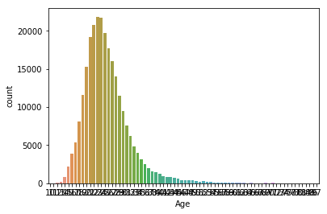

```python
sns.countplot(age_df)
```

```python
data_df.loc[data_df['Medal'].isnull()]
```

[output not shown]

```python
medalists_df = data_df.loc[~data_df['Medal'].isnull()]
```

```python
medalists_df
```

|  | ID | Name | Sex | Age | Height | Weight | Team | NOC | Games | Year | Season | City | Sport | Event | Medal | region | notes |
| --- | --- | --- | --- | --- | --- | --- | --- | --- | --- | --- | --- | --- | --- | --- | --- | --- | --- |
| 3 | 4 | Edgar Lindenau Aabye | M | 34.0 | NaN | NaN | Denmark/Sweden | DEN | 1900 Summer | 1900 | Summer | Paris | Tug-Of-War | Tug-Of-War Men's Tug-Of-War | Gold | Denmark | NaN |
| 37 | 15 | Arvo Ossian Aaltonen | M | 30.0 | NaN | NaN | Finland | FIN | 1920 Summer | 1920 | Summer | Antwerpen | Swimming | Swimming Men's 200 metres Breaststroke | Bronze | Finland | NaN |
| 38 | 15 | Arvo Ossian Aaltonen | M | 30.0 | NaN | NaN | Finland | FIN | 1920 Summer | 1920 | Summer | Antwerpen | Swimming | Swimming Men's 400 metres Breaststroke | Bronze | Finland | NaN |
| 40 | 16 | Juhamatti Tapio Aaltonen | M | 28.0 | 184.0 | 85.0 | Finland | FIN | 2014 Winter | 2014 | Winter | Sochi | Ice Hockey | Ice Hockey Men's Ice Hockey | Bronze | Finland | NaN |
| 41 | 17 | Paavo Johannes Aaltonen | M | 28.0 | 175.0 | 64.0 | Finland | FIN | 1948 Summer | 1948 | Summer | London | Gymnastics | Gymnastics Men's Individual All-Around | Bronze | Finland | NaN |
| 42 | 17 | Paavo Johannes Aaltonen | M | 28.0 | 175.0 | 64.0 | Finland | FIN | 1948 Summer | 1948 | Summer | London | Gymnastics | Gymnastics Men's Team All-Around | Gold | Finland | NaN |
| 44 | 17 | Paavo Johannes Aaltonen | M | 28.0 | 175.0 | 64.0 | Finland | FIN | 1948 Summer | 1948 | Summer | London | Gymnastics | Gymnastics Men's Horse Vault | Gold | Finland | NaN |
| 48 | 17 | Paavo Johannes Aaltonen | M | 28.0 | 175.0 | 64.0 | Finland | FIN | 1948 Summer | 1948 | Summer | London | Gymnastics | Gymnastics Men's Pommelled Horse | Gold | Finland | NaN |
| 50 | 17 | Paavo Johannes Aaltonen | M | 32.0 | 175.0 | 64.0 | Finland | FIN | 1952 Summer | 1952 | Summer | Helsinki | Gymnastics | Gymnastics Men's Team All-Around | Bronze | Finland | NaN |
| 60 | 20 | Kjetil Andr Aamodt | M | 20.0 | 176.0 | 85.0 | Norway | NOR | 1992 Winter | 1992 | Winter | Albertville | Alpine Skiing | Alpine Skiing Men's Super G | Gold | Norway | NaN |
| 61 | 20 | Kjetil Andr Aamodt | M | 20.0 | 176.0 | 85.0 | Norway | NOR | 1992 Winter | 1992 | Winter | Albertville | Alpine Skiing | Alpine Skiing Men's Giant Slalom | Bronze | Norway | NaN |
| 63 | 20 | Kjetil Andr Aamodt | M | 22.0 | 176.0 | 85.0 | Norway | NOR | 1994 Winter | 1994 | Winter | Lillehammer | Alpine Skiing | Alpine Skiing Men's Downhill | Silver | Norway | NaN |
| 64 | 20 | Kjetil Andr Aamodt | M | 22.0 | 176.0 | 85.0 | Norway | NOR | 1994 Winter | 1994 | Winter | Lillehammer | Alpine Skiing | Alpine Skiing Men's Super G | Bronze | Norway | NaN |
| 67 | 20 | Kjetil Andr Aamodt | M | 22.0 | 176.0 | 85.0 | Norway | NOR | 1994 Winter | 1994 | Winter | Lillehammer | Alpine Skiing | Alpine Skiing Men's Combined | Silver | Norway | NaN |
| 73 | 20 | Kjetil Andr Aamodt | M | 30.0 | 176.0 | 85.0 | Norway | NOR | 2002 Winter | 2002 | Winter | Salt Lake City | Alpine Skiing | Alpine Skiing Men's Super G | Gold | Norway | NaN |
| 76 | 20 | Kjetil Andr Aamodt | M | 30.0 | 176.0 | 85.0 | Norway | NOR | 2002 Winter | 2002 | Winter | Salt Lake City | Alpine Skiing | Alpine Skiing Men's Combined | Gold | Norway | NaN |
| 78 | 20 | Kjetil Andr Aamodt | M | 34.0 | 176.0 | 85.0 | Norway | NOR | 2006 Winter | 2006 | Winter | Torino | Alpine Skiing | Alpine Skiing Men's Super G | Gold | Norway | NaN |
| 79 | 21 | Ragnhild Margrethe Aamodt | F | 27.0 | 163.0 | NaN | Norway | NOR | 2008 Summer | 2008 | Summer | Beijing | Handball | Handball Women's Handball | Gold | Norway | NaN |
| 86 | 25 | Alf Lied Aanning | M | 24.0 | NaN | NaN | Norway | NOR | 1920 Summer | 1920 | Summer | Antwerpen | Gymnastics | Gymnastics Men's Team All-Around, Free System | Silver | Norway | NaN |
| 91 | 29 | Willemien Aardenburg | F | 22.0 | NaN | NaN | Netherlands | NED | 1988 Summer | 1988 | Summer | Seoul | Hockey | Hockey Women's Hockey | Bronze | Netherlands | NaN |
| 92 | 30 | Pepijn Aardewijn | M | 26.0 | 189.0 | 72.0 | Netherlands | NED | 1996 Summer | 1996 | Summer | Atlanta | Rowing | Rowing Men's Lightweight Double Sculls | Silver | Netherlands | NaN |
| 105 | 37 | Ann Kristin Aarnes | F | 23.0 | 182.0 | 64.0 | Norway | NOR | 1996 Summer | 1996 | Summer | Atlanta | Football | Football Women's Football | Bronze | Norway | NaN |
| 106 | 38 | Karl Jan Aas | M | 20.0 | NaN | NaN | Norway | NOR | 1920 Summer | 1920 | Summer | Antwerpen | Gymnastics | Gymnastics Men's Team All-Around, Free System | Silver | Norway | NaN |
| 110 | 40 | Roald Edgar Aas | M | 23.0 | NaN | NaN | Norway | NOR | 1952 Winter | 1952 | Winter | Oslo | Speed Skating | Speed Skating Men's 1,500 metres | Bronze | Norway | NaN |
| 113 | 40 | Roald Edgar Aas | M | 31.0 | NaN | NaN | Norway | NOR | 1960 Winter | 1960 | Winter | Squaw Valley | Speed Skating | Speed Skating Men's 1,500 metres | Gold | Norway | NaN |
| 117 | 42 | Thomas Valentin Aas | M | 25.0 | NaN | NaN | Taifun | NOR | 1912 Summer | 1912 | Summer | Stockholm | Sailing | Sailing Mixed 8 metres | Gold | Norway | NaN |
| 150 | 56 | Ren Abadie | M | 21.0 | NaN | NaN | France | FRA | 1956 Summer | 1956 | Summer | Melbourne | Cycling | Cycling Men's Road Race, Team | Gold | France | NaN |
| 158 | 62 | Giovanni Abagnale | M | 21.0 | 198.0 | 90.0 | Italy | ITA | 2016 Summer | 2016 | Summer | Rio de Janeiro | Rowing | Rowing Men's Coxless Pairs | Bronze | Italy | NaN |
| 159 | 63 | Jos Luis Abajo Gmez | M | 30.0 | 194.0 | 87.0 | Spain | ESP | 2008 Summer | 2008 | Summer | Beijing | Fencing | Fencing Men's epee, Individual | Bronze | Spain | NaN |
| 161 | 65 | Patimat Abakarova | F | 21.0 | 165.0 | 49.0 | Azerbaijan | AZE | 2016 Summer | 2016 | Summer | Rio de Janeiro | Taekwondo | Taekwondo Women's Flyweight | Bronze | Azerbaijan | NaN |
| ... | ... | ... | ... | ... | ... | ... | ... | ... | ... | ... | ... | ... | ... | ... | ... | ... | ... |
| 270914 | 135481 | Jules Alexis "Louis" Zutter | M | 30.0 | NaN | NaN | Switzerland | SUI | 1896 Summer | 1896 | Summer | Athina | Gymnastics | Gymnastics Men's Horse Vault | Silver | Switzerland | NaN |
| 270915 | 135481 | Jules Alexis "Louis" Zutter | M | 30.0 | NaN | NaN | Switzerland | SUI | 1896 Summer | 1896 | Summer | Athina | Gymnastics | Gymnastics Men's Parallel Bars | Silver | Switzerland | NaN |
| 270917 | 135481 | Jules Alexis "Louis" Zutter | M | 30.0 | NaN | NaN | Switzerland | SUI | 1896 Summer | 1896 | Summer | Athina | Gymnastics | Gymnastics Men's Pommelled Horse | Gold | Switzerland | NaN |
| 270931 | 135486 | Viktor Valeryevich Zuyev | M | 21.0 | 188.0 | 91.0 | Belarus | BLR | 2004 Summer | 2004 | Summer | Athina | Boxing | Boxing Men's Heavyweight | Silver | Belarus | NaN |
| 270934 | 135488 | Nataliya Vladimirovna Zuyeva | F | 19.0 | 176.0 | 62.0 | Russia | RUS | 2008 Summer | 2008 | Summer | Beijing | Rhythmic Gymnastics | Rhythmic Gymnastics Women's Group | Gold | Russia | NaN |
| 270939 | 135489 | Anastasiya Valeryevna Zuyeva-Fesikova | F | 22.0 | 182.0 | 71.0 | Russia | RUS | 2012 Summer | 2012 | Summer | London | Swimming | Swimming Women's 200 metres Backstroke | Silver | Russia | NaN |
| 270946 | 135491 | Marijan uej | M | 22.0 | 186.0 | 93.0 | Yugoslavia | YUG | 1956 Summer | 1956 | Summer | Melbourne | Water Polo | Water Polo Men's Water Polo | Silver | Serbia | Yugoslavia |
| 270960 | 135498 | Denis vegelj | M | 20.0 | NaN | NaN | Slovenia | SLO | 1992 Summer | 1992 | Summer | Barcelona | Rowing | Rowing Men's Coxless Pairs | Bronze | Slovenia | NaN |
| 270969 | 135501 | Ellina Aleksandrovna Zvereva (Kisheyeva-) | F | 35.0 | 183.0 | 100.0 | Belarus | BLR | 1996 Summer | 1996 | Summer | Atlanta | Athletics | Athletics Women's Discus Throw | Bronze | Belarus | NaN |
| 270970 | 135501 | Ellina Aleksandrovna Zvereva (Kisheyeva-) | F | 39.0 | 183.0 | 100.0 | Belarus | BLR | 2000 Summer | 2000 | Summer | Sydney | Athletics | Athletics Women's Discus Throw | Gold | Belarus | NaN |
| 270976 | 135502 | Nataliya Maratovna "Natasha" Zvereva | F | 21.0 | 172.0 | 60.0 | Unified Team | EUN | 1992 Summer | 1992 | Summer | Barcelona | Tennis | Tennis Women's Doubles | Bronze | Russia | NaN |
| 270981 | 135503 | Zurab Zviadauri | M | 23.0 | 182.0 | 90.0 | Georgia | GEO | 2004 Summer | 2004 | Summer | Athina | Judo | Judo Men's Middleweight | Gold | Georgia | NaN |
| 270982 | 135504 | Viktor Oleksandrovych Zviahintsev | M | 25.0 | 178.0 | 79.0 | Soviet Union | URS | 1976 Summer | 1976 | Summer | Montreal | Football | Football Men's Football | Bronze | Russia | NaN |
| 270986 | 135508 | Vera Igorevna Zvonaryova | F | 23.0 | 172.0 | 59.0 | Russia | RUS | 2008 Summer | 2008 | Summer | Beijing | Tennis | Tennis Women's Singles | Bronze | Russia | NaN |
| 271009 | 135520 | Julia Zwehl | F | 28.0 | 167.0 | 60.0 | Germany | GER | 2004 Summer | 2004 | Summer | Athina | Hockey | Hockey Women's Hockey | Gold | Germany | NaN |
| 271010 | 135521 | Anton Zwerina | M | 23.0 | NaN | 66.0 | Austria | AUT | 1924 Summer | 1924 | Summer | Paris | Weightlifting | Weightlifting Men's Lightweight | Silver | Austria | NaN |
| 271013 | 135522 | Klaas Erik "Klaas-Erik" Zwering | M | 23.0 | 189.0 | 80.0 | Netherlands | NED | 2004 Summer | 2004 | Summer | Athina | Swimming | Swimming Men's 4 x 100 metres Freestyle Relay | Silver | Netherlands | NaN |
| 271015 | 135523 | Ronald Ferdinand "Ron" Zwerver | M | 25.0 | 200.0 | 93.0 | Netherlands | NED | 1992 Summer | 1992 | Summer | Barcelona | Volleyball | Volleyball Men's Volleyball | Silver | Netherlands | NaN |
| 271016 | 135523 | Ronald Ferdinand "Ron" Zwerver | M | 29.0 | 200.0 | 93.0 | Netherlands | NED | 1996 Summer | 1996 | Summer | Atlanta | Volleyball | Volleyball Men's Volleyball | Gold | Netherlands | NaN |
| 271019 | 135525 | Martin Zwicker | M | 29.0 | 175.0 | 64.0 | Germany | GER | 2016 Summer | 2016 | Summer | Rio de Janeiro | Hockey | Hockey Men's Hockey | Bronze | Germany | NaN |
| 271032 | 135535 | Claudia Antoinette Zwiers | F | 22.0 | 181.0 | 78.0 | Netherlands | NED | 1996 Summer | 1996 | Summer | Atlanta | Judo | Judo Women's Middleweight | Bronze | Netherlands | NaN |
| 271046 | 135544 | Krzysztof Zwoliski | M | 21.0 | 175.0 | 70.0 | Poland | POL | 1980 Summer | 1980 | Summer | Moskva | Athletics | Athletics Men's 4 x 100 metres Relay | Silver | Poland | NaN |
| 271048 | 135545 | Henk Jan Zwolle | M | 27.0 | 197.0 | 93.0 | Netherlands | NED | 1992 Summer | 1992 | Summer | Barcelona | Rowing | Rowing Men's Double Sculls | Bronze | Netherlands | NaN |
| 271049 | 135545 | Henk Jan Zwolle | M | 31.0 | 197.0 | 93.0 | Netherlands | NED | 1996 Summer | 1996 | Summer | Atlanta | Rowing | Rowing Men's Coxed Eights | Gold | Netherlands | NaN |
| 271076 | 135553 | Galina Ivanovna Zybina (-Fyodorova) | F | 21.0 | 168.0 | 80.0 | Soviet Union | URS | 1952 Summer | 1952 | Summer | Helsinki | Athletics | Athletics Women's Shot Put | Gold | Russia | NaN |
| 271078 | 135553 | Galina Ivanovna Zybina (-Fyodorova) | F | 25.0 | 168.0 | 80.0 | Soviet Union | URS | 1956 Summer | 1956 | Summer | Melbourne | Athletics | Athletics Women's Shot Put | Silver | Russia | NaN |
| 271080 | 135553 | Galina Ivanovna Zybina (-Fyodorova) | F | 33.0 | 168.0 | 80.0 | Soviet Union | URS | 1964 Summer | 1964 | Summer | Tokyo | Athletics | Athletics Women's Shot Put | Bronze | Russia | NaN |
| 271082 | 135554 | Bogusaw Zych | M | 28.0 | 182.0 | 82.0 | Poland | POL | 1980 Summer | 1980 | Summer | Moskva | Fencing | Fencing Men's Foil, Team | Bronze | Poland | NaN |
| 271102 | 135563 | Olesya Nikolayevna Zykina | F | 19.0 | 171.0 | 64.0 | Russia | RUS | 2000 Summer | 2000 | Summer | Sydney | Athletics | Athletics Women's 4 x 400 metres Relay | Bronze | Russia | NaN |
| 271103 | 135563 | Olesya Nikolayevna Zykina | F | 23.0 | 171.0 | 64.0 | Russia | RUS | 2004 Summer | 2004 | Summer | Athina | Athletics | Athletics Women's 4 x 400 metres Relay | Silver | Russia | NaN |

39783 rows × 17 columns

```python
def plot_column(my_df, col, chart_type='Histogram', dtype=int,
               bin_size=25):
    temp_df = pd.to_numeric(my_df[col], errors='coerce')
    temp_df = temp_df.dropna()
    temp_df = temp_df.astype(dtype)
    if chart_type=='Histogram':
        ax = sns.countplot(temp_df)
    elif chart_type=='Density':
        ax = sns.distplot(temp_df)
    xmin, xmax = ax.get_xlim()
    ax.set_xticks(np.round(np.linspace(xmin, xmax, bin_size), 2))
    plt.tight_layout()
    plt.locator_params(axis='y', nbins=6)
    plt.show()
```

[figure not shown]

```python
plot_column(medalists_df, 'Age')
```

### Calculate Skewness

```python
from scipy.stats import skew
age_df = pd.to_numeric(medalists_df['Age'], errors='coerce')
age_df = age_df.dropna()
age_df = age_df.astype(int)
print("Skewness is {}".format(skew(age_df)))
print("Mean is {}".format(np.mean(age_df)))
print("Median is {}".format(np.median(age_df)))
```

```
Skewness is 1.497531959387686
Mean is 25.925174771452717
Median is 25.0
```

[figure not shown]

```python
plot_column(medalists_df, 'Height', bin_size=15)
```

```python
Height_df = pd.to_numeric(medalists_df['Height'], errors='coerce')
Height_df = Height_df.dropna()
Height_df = Height_df.astype(int)
print("Skewness is {}".format(skew(Height_df)))
print("Mean is {}".format(np.mean(Height_df)))
print("Median is {}".format(np.median(Height_df)))
```

```
Skewness is 0.046825246979302765
Mean is 177.55419670442842
Median is 178.0
```

[figure not shown]

```python
plot_column(medalists_df, 'Weight', bin_size=15)
```

```python
Weight_df = pd.to_numeric(medalists_df['Weight'], errors='coerce')
Weight_df = Weight_df.dropna()
Weight_df = Weight_df.astype(int)
print("Skewness is {}".format(skew(Weight_df)))
print("Mean is {}".format(np.mean(Weight_df)))
print("Median is {}".format(np.median(Weight_df)))
```

```
Skewness is 0.6921002780813605
Mean is 73.76723798266352
Median is 73.0
```

[figure not shown]

```python
sports_df = medalists_df[~medalists_df['Sport'].isnull()]
sns.countplot(medalists_df['Sport'])
```

```python
sum(medalists_df['Sport'].isnull())
```

[output not shown]

```python
sports_count=medalists_df['Sport'].value_counts().nlargest(25).to_frame()
```

```python
#sports_count.reset_index(inplace=True)
print(sports_count)
```

```
                      Sport
Athletics              3969
Swimming               3048
Rowing                 2945
Gymnastics             2256
Fencing                1743
Football               1571
Ice Hockey             1530
Hockey                 1528
Wrestling              1296
Cycling                1263
Sailing                1232
Shooting               1228
Canoeing               1165
Basketball             1080
Handball               1060
Water Polo             1057
Volleyball              969
Equestrianism           965
Boxing                  944
Cross Country Skiing    776
Weightlifting           646
Speed Skating           580
Judo                    547
Alpine Skiing           428
Diving                  427
```

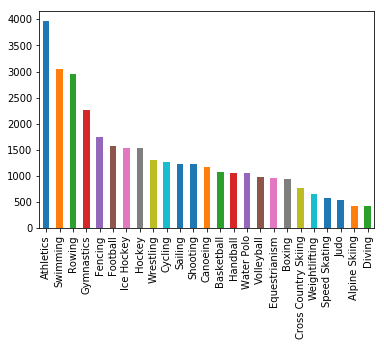

```python
ax = sports_count.plot.bar(y='Sport')
ax.get_legend().remove()
```

```python
year_count_df=data_df['Year'].value_counts().to_frame()
```

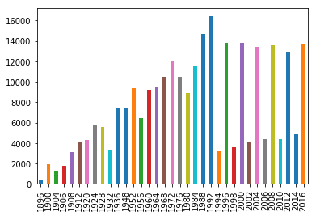

```python
year_count_df.sort_index(inplace=True)
ax = year_count_df.plot.bar(y='Year')
ax.get_legend().remove()
```

# Bivariate examples

```python
import numpy as np
import pandas as pd
import matplotlib.pyplot as plt
import seaborn as sns
%matplotlib inline
```

```python
titanic_data_df = pd.read_csv('titanic-data.csv')
```

1. **Survived:** Outcome of survival (0 = No; 1 = Yes)
2. **Pclass:** Socio-economic class (1 = Upper class; 2 = Middle class; 3 = Lower class)
3. **Name:** Name of passenger
4. **Sex:** Sex of the passenger
5. **Age:** Age of the passenger (Some entries contain NaN)
6. **SibSp:** Number of siblings and spouses of the passenger aboard
7. **Parch:** Number of parents and children of the passenger aboard
8. **Ticket:** Ticket number of the passenger
9. **Fare:** Fare paid by the passenger
10. **Cabin** Cabin number of the passenger (Some entries contain NaN)
11. **Embarked:** Port of embarkation of the passenger (C = Cherbourg; Q = Queenstown; S = Southampton)

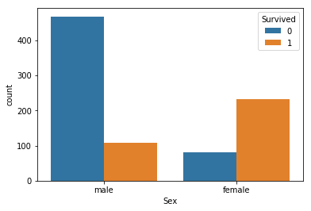

```python
g = sns.countplot(x='Sex', hue='Survived', data=titanic_data_df)
```

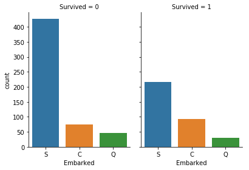

```python
g = sns.catplot(x="Embarked", col="Survived",
                 data=titanic_data_df, kind="count",
                 height=4, aspect=.7);
```

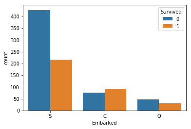

```python
g = sns.countplot(x='Embarked', hue='Survived', data=titanic_data_df)
```

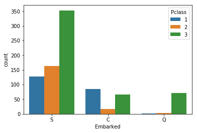

```python
g = sns.countplot(x='Embarked', hue='Pclass', data=titanic_data_df)
```

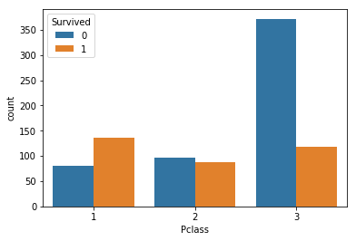

```python
g = sns.countplot(x='Pclass', hue='Survived', data=titanic_data_df)
```

## Add a new column - Family size

I will be adding a new column 'Family Size' which will be the SibSp and Parch + 1

```python
#Function to add new column 'FamilySize'
def add_family(df):
    df['FamilySize'] = df['SibSp'] + df['Parch'] + 1
    return df

titanic_data_df = add_family(titanic_data_df)
titanic_data_df.head(10)
```

|  | PassengerId | Survived | Pclass | Name | Sex | Age | SibSp | Parch | Ticket | Fare | Cabin | Embarked | FamilySize |
| --- | --- | --- | --- | --- | --- | --- | --- | --- | --- | --- | --- | --- | --- |
| 0 | 1 | 0 | 3 | Braund, Mr. Owen Harris | male | 22.0 | 1 | 0 | A/5 21171 | 7.2500 | NaN | S | 2 |
| 1 | 2 | 1 | 1 | Cumings, Mrs. John Bradley (Florence Briggs Th... | female | 38.0 | 1 | 0 | PC 17599 | 71.2833 | C85 | C | 2 |
| 2 | 3 | 1 | 3 | Heikkinen, Miss. Laina | female | 26.0 | 0 | 0 | STON/O2. 3101282 | 7.9250 | NaN | S | 1 |
| 3 | 4 | 1 | 1 | Futrelle, Mrs. Jacques Heath (Lily May Peel) | female | 35.0 | 1 | 0 | 113803 | 53.1000 | C123 | S | 2 |
| 4 | 5 | 0 | 3 | Allen, Mr. William Henry | male | 35.0 | 0 | 0 | 373450 | 8.0500 | NaN | S | 1 |
| 5 | 6 | 0 | 3 | Moran, Mr. James | male | NaN | 0 | 0 | 330877 | 8.4583 | NaN | Q | 1 |
| 6 | 7 | 0 | 1 | McCarthy, Mr. Timothy J | male | 54.0 | 0 | 0 | 17463 | 51.8625 | E46 | S | 1 |
| 7 | 8 | 0 | 3 | Palsson, Master. Gosta Leonard | male | 2.0 | 3 | 1 | 349909 | 21.0750 | NaN | S | 5 |
| 8 | 9 | 1 | 3 | Johnson, Mrs. Oscar W (Elisabeth Vilhelmina Berg) | female | 27.0 | 0 | 2 | 347742 | 11.1333 | NaN | S | 3 |
| 9 | 10 | 1 | 2 | Nasser, Mrs. Nicholas (Adele Achem) | female | 14.0 | 1 | 0 | 237736 | 30.0708 | NaN | C | 2 |

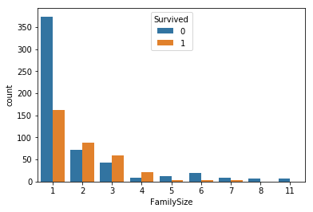

```python
g = sns.countplot(x="FamilySize", hue="Survived",
                 data=titanic_data_df);
```

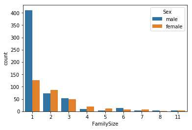

```python
g = sns.countplot(x="FamilySize", hue="Sex",
                 data=titanic_data_df);
```

## Add a new column - Age Group

```python
age_df = titanic_data_df[~titanic_data_df['Age'].isnull()]
#Make bins and group all passengers into these bins and store those values in a new column 'ageGroup'
age_bins = ['0-9', '10-19', '20-29', '30-39', '40-49', '50-59', '60-69', '70-79']
age_df['ageGroup'] = pd.cut(titanic_data_df.Age, range(0, 81, 10), right=False, labels=age_bins)
```

```python
#age_df[['Age', 'ageGroup']]
```

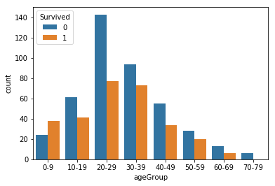

```python
sns.countplot(x='ageGroup', hue='Survived', data=age_df)
```

# Multivariate

### Dataset : https://www.kaggle.com/abcsds/pokemon

```python
import pandas as pd
import numpy as np
import seaborn as sns
import matplotlib.pyplot as plt
%matplotlib inline
```

```python
pokemon_df = pd.read_csv('Pokemon.csv', index_col=0)
```

```python
pokemon_df.head()
```

| # | Name | Type 1 | Type 2 | Total | HP | Attack | Defense | Sp. Atk | Sp. Def | Speed | Generation | Legendary |
| --- | --- | --- | --- | --- | --- | --- | --- | --- | --- | --- | --- | --- |
| 1 | Bulbasaur | Grass | Poison | 318 | 45 | 49 | 49 | 65 | 65 | 45 | 1 | False |
| 2 | Ivysaur | Grass | Poison | 405 | 60 | 62 | 63 | 80 | 80 | 60 | 1 | False |
| 3 | Venusaur | Grass | Poison | 525 | 80 | 82 | 83 | 100 | 100 | 80 | 1 | False |
| 3 | VenusaurMega Venusaur | Grass | Poison | 625 | 80 | 100 | 123 | 122 | 120 | 80 | 1 | False |
| 4 | Charmander | Fire | NaN | 309 | 39 | 52 | 43 | 60 | 50 | 65 | 1 | False |

```python
pokemon_df.info()
```

```
<class 'pandas.core.frame.DataFrame'>
Int64Index: 800 entries, 1 to 721
Data columns (total 12 columns):
Name          800 non-null object
Type 1        800 non-null object
Type 2        414 non-null object
Total         800 non-null int64
HP            800 non-null int64
Attack        800 non-null int64
Defense       800 non-null int64
Sp. Atk       800 non-null int64
Sp. Def       800 non-null int64
Speed         800 non-null int64
Generation    800 non-null int64
Legendary     800 non-null bool
dtypes: bool(1), int64(8), object(3)
memory usage: 75.8+ KB
```

```python
pokemon_df.describe()
```

|  | Total | HP | Attack | Defense | Sp. Atk | Sp. Def | Speed | Generation |
| --- | --- | --- | --- | --- | --- | --- | --- | --- |
| count | 800.00000 | 800.000000 | 800.000000 | 800.000000 | 800.000000 | 800.000000 | 800.000000 | 800.00000 |
| mean | 435.10250 | 69.258750 | 79.001250 | 73.842500 | 72.820000 | 71.902500 | 68.277500 | 3.32375 |
| std | 119.96304 | 25.534669 | 32.457366 | 31.183501 | 32.722294 | 27.828916 | 29.060474 | 1.66129 |
| min | 180.00000 | 1.000000 | 5.000000 | 5.000000 | 10.000000 | 20.000000 | 5.000000 | 1.00000 |
| 25% | 330.00000 | 50.000000 | 55.000000 | 50.000000 | 49.750000 | 50.000000 | 45.000000 | 2.00000 |
| 50% | 450.00000 | 65.000000 | 75.000000 | 70.000000 | 65.000000 | 70.000000 | 65.000000 | 3.00000 |
| 75% | 515.00000 | 80.000000 | 100.000000 | 90.000000 | 95.000000 | 90.000000 | 90.000000 | 5.00000 |
| max | 780.00000 | 255.000000 | 190.000000 | 230.000000 | 194.000000 | 230.000000 | 180.000000 | 6.00000 |

### Dealing with Missing values

```python
pokemon_df['Type 2'].fillna(value='NA', inplace=True)
```

```python
pokemon_df.info()
```

```
<class 'pandas.core.frame.DataFrame'>
Int64Index: 800 entries, 1 to 721
Data columns (total 12 columns):
Name          800 non-null object
Type 1        800 non-null object
Type 2        800 non-null object
Total         800 non-null int64
HP            800 non-null int64
Attack        800 non-null int64
Defense       800 non-null int64
Sp. Atk       800 non-null int64
Sp. Def       800 non-null int64
Speed         800 non-null int64
Generation    800 non-null int64
Legendary     800 non-null bool
dtypes: bool(1), int64(8), object(3)
memory usage: 75.8+ KB
```

# Store Legendary Pokemon Seperately

```python
legendry_df = pokemon_df[pokemon_df['Legendary']==True]
```

## Pokemon count by Type 1

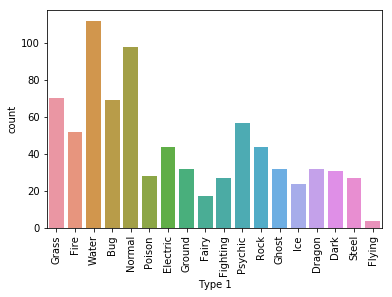

```python
ax = sns.countplot(pokemon_df['Type 1'])
g= ax.set_xticklabels(ax.get_xticklabels(), rotation=90)
```

## Pokemon count by Type 2

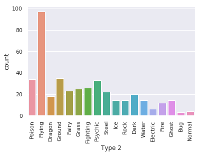

```python
ax = sns.countplot(pokemon_df[pokemon_df['Type 2']!='NA']['Type 2'])
g= ax.set_xticklabels(ax.get_xticklabels(), rotation=90)
```

```python
pokemon_df.info()
```

[output not shown]

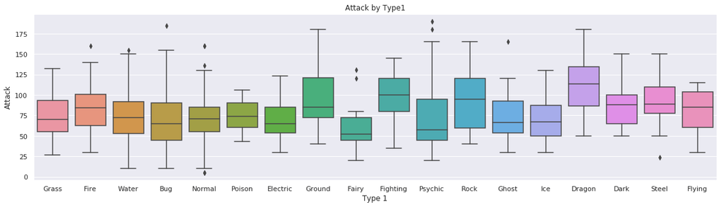

```python
plt.subplots(figsize = (20,5))
plt.title('Attack by Type1')
sns.boxplot(x = "Type 1", y = "Attack",data = pokemon_df)
```

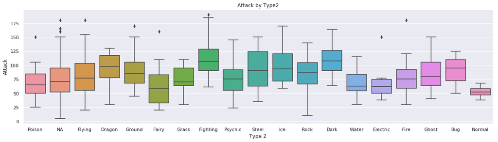

```python
plt.subplots(figsize = (20,5))
plt.title('Attack by Type2')
sns.boxplot(x = "Type 2", y = "Attack",data = pokemon_df)
```

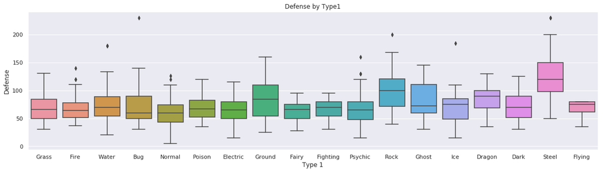

```python
plt.subplots(figsize = (20,5))
plt.title('Defense by Type1')
sns.boxplot(x = "Type 1", y = "Defense",data = pokemon_df)
```

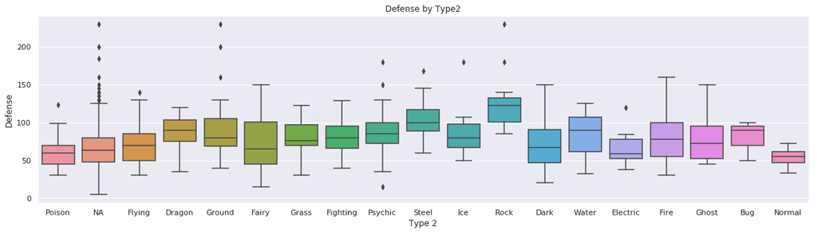

```python
plt.subplots(figsize = (20,5))
plt.title('Defense by Type2')
sns.boxplot(x = "Type 2", y = "Defense",data = pokemon_df)
```

```python
type_grouped = pokemon_df[pokemon_df['Type 2']!='NA'].groupby(['Type 1', 'Type 2']).size()
print(type_grouped)
```

```
Type 1    Type 2
Bug       Electric     2
          Fighting     2
          Fire         2
          Flying      14
          Ghost        1
          Grass        6
          Ground       2
          Poison      12
          Rock         3
          Steel        7
          Water        1
Dark      Dragon       3
          Fighting     2
          Fire         3
          Flying       5
          Ghost        2
          Ice          2
          Psychic      2
          Steel        2
Dragon    Electric     1
          Fairy        1
          Fire         1
          Flying       6
          Ground       5
          Ice          3
          Psychic      4
Electric  Dragon       1
          Fairy        1
          Fire         1
          Flying       5
                      ..
Rock      Fighting     1
          Flying       4
          Grass        2
          Ground       6
          Ice          2
          Psychic      2
          Steel        3
          Water        6
```

[output cut: 8 more lines]

```
Water     Dark         6
          Dragon       2
          Electric     2
          Fairy        2
          Fighting     3
          Flying       7
          Ghost        2
          Grass        3
          Ground      10
          Ice          3
          Poison       3
          Psychic      5
          Rock         4
          Steel        1
Length: 136, dtype: int64
```

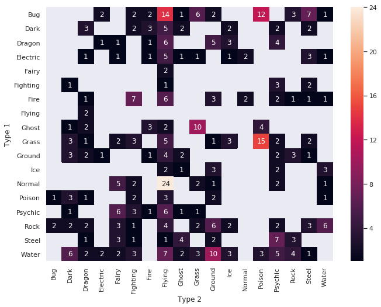

```python
sns.set(rc={'figure.figsize':(11,8)})
sns.heatmap(
    type_grouped.unstack(),
    annot=True,
)
plt.xticks(rotation=90)
plt.show()
```

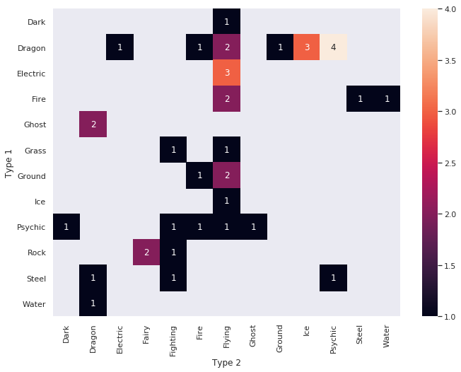

```python
type_grouped = legendry_df[legendry_df['Type 2']!='NA'].groupby(['Type 1', 'Type 2']).size()
sns.set(rc={'figure.figsize':(11,8)})
sns.heatmap(
    type_grouped.unstack(),
    annot=True,
)
plt.xticks(rotation=90)
plt.show()
```

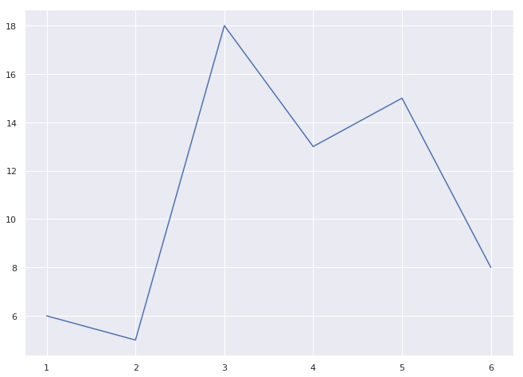

```python
pokemon_gen = legendry_df.groupby('Generation')['Name'].count()
sns.lineplot(data=pokemon_gen)
```

```python
legendry_df[legendry_df['Generation']==3]
```

| # | Name | Type 1 | Type 2 | Total | HP | Attack | Defense | Sp. Atk | Sp. Def | Speed | Generation | Legendary |
| --- | --- | --- | --- | --- | --- | --- | --- | --- | --- | --- | --- | --- |
| 377 | Regirock | Rock | NA | 580 | 80 | 100 | 200 | 50 | 100 | 50 | 3 | True |
| 378 | Regice | Ice | NA | 580 | 80 | 50 | 100 | 100 | 200 | 50 | 3 | True |
| 379 | Registeel | Steel | NA | 580 | 80 | 75 | 150 | 75 | 150 | 50 | 3 | True |
| 380 | Latias | Dragon | Psychic | 600 | 80 | 80 | 90 | 110 | 130 | 110 | 3 | True |
| 380 | LatiasMega Latias | Dragon | Psychic | 700 | 80 | 100 | 120 | 140 | 150 | 110 | 3 | True |
| 381 | Latios | Dragon | Psychic | 600 | 80 | 90 | 80 | 130 | 110 | 110 | 3 | True |
| 381 | LatiosMega Latios | Dragon | Psychic | 700 | 80 | 130 | 100 | 160 | 120 | 110 | 3 | True |
| 382 | Kyogre | Water | NA | 670 | 100 | 100 | 90 | 150 | 140 | 90 | 3 | True |
| 382 | KyogrePrimal Kyogre | Water | NA | 770 | 100 | 150 | 90 | 180 | 160 | 90 | 3 | True |
| 383 | Groudon | Ground | NA | 670 | 100 | 150 | 140 | 100 | 90 | 90 | 3 | True |
| 383 | GroudonPrimal Groudon | Ground | Fire | 770 | 100 | 180 | 160 | 150 | 90 | 90 | 3 | True |
| 384 | Rayquaza | Dragon | Flying | 680 | 105 | 150 | 90 | 150 | 90 | 95 | 3 | True |
| 384 | RayquazaMega Rayquaza | Dragon | Flying | 780 | 105 | 180 | 100 | 180 | 100 | 115 | 3 | True |
| 385 | Jirachi | Steel | Psychic | 600 | 100 | 100 | 100 | 100 | 100 | 100 | 3 | True |
| 386 | DeoxysNormal Forme | Psychic | NA | 600 | 50 | 150 | 50 | 150 | 50 | 150 | 3 | True |
| 386 | DeoxysAttack Forme | Psychic | NA | 600 | 50 | 180 | 20 | 180 | 20 | 150 | 3 | True |
| 386 | DeoxysDefense Forme | Psychic | NA | 600 | 50 | 70 | 160 | 70 | 160 | 90 | 3 | True |
| 386 | DeoxysSpeed Forme | Psychic | NA | 600 | 50 | 95 | 90 | 95 | 90 | 180 | 3 | True |

```python
legendry_df[legendry_df['Generation']==5]
```

| # | Name | Type 1 | Type 2 | Total | HP | Attack | Defense | Sp. Atk | Sp. Def | Speed | Generation | Legendary |
| --- | --- | --- | --- | --- | --- | --- | --- | --- | --- | --- | --- | --- |
| 494 | Victini | Psychic | Fire | 600 | 100 | 100 | 100 | 100 | 100 | 100 | 5 | True |
| 638 | Cobalion | Steel | Fighting | 580 | 91 | 90 | 129 | 90 | 72 | 108 | 5 | True |
| 639 | Terrakion | Rock | Fighting | 580 | 91 | 129 | 90 | 72 | 90 | 108 | 5 | True |
| 640 | Virizion | Grass | Fighting | 580 | 91 | 90 | 72 | 90 | 129 | 108 | 5 | True |
| 641 | TornadusIncarnate Forme | Flying | NA | 580 | 79 | 115 | 70 | 125 | 80 | 111 | 5 | True |
| 641 | TornadusTherian Forme | Flying | NA | 580 | 79 | 100 | 80 | 110 | 90 | 121 | 5 | True |
| 642 | ThundurusIncarnate Forme | Electric | Flying | 580 | 79 | 115 | 70 | 125 | 80 | 111 | 5 | True |
| 642 | ThundurusTherian Forme | Electric | Flying | 580 | 79 | 105 | 70 | 145 | 80 | 101 | 5 | True |
| 643 | Reshiram | Dragon | Fire | 680 | 100 | 120 | 100 | 150 | 120 | 90 | 5 | True |
| 644 | Zekrom | Dragon | Electric | 680 | 100 | 150 | 120 | 120 | 100 | 90 | 5 | True |
| 645 | LandorusIncarnate Forme | Ground | Flying | 600 | 89 | 125 | 90 | 115 | 80 | 101 | 5 | True |
| 645 | LandorusTherian Forme | Ground | Flying | 600 | 89 | 145 | 90 | 105 | 80 | 91 | 5 | True |
| 646 | Kyurem | Dragon | Ice | 660 | 125 | 130 | 90 | 130 | 90 | 95 | 5 | True |
| 646 | KyuremBlack Kyurem | Dragon | Ice | 700 | 125 | 170 | 100 | 120 | 90 | 95 | 5 | True |
| 646 | KyuremWhite Kyurem | Dragon | Ice | 700 | 125 | 120 | 90 | 170 | 100 | 95 | 5 | True |

```python
max_type1_per_gen = pokemon_df.groupby(['Generation','Type 1']).size()
```

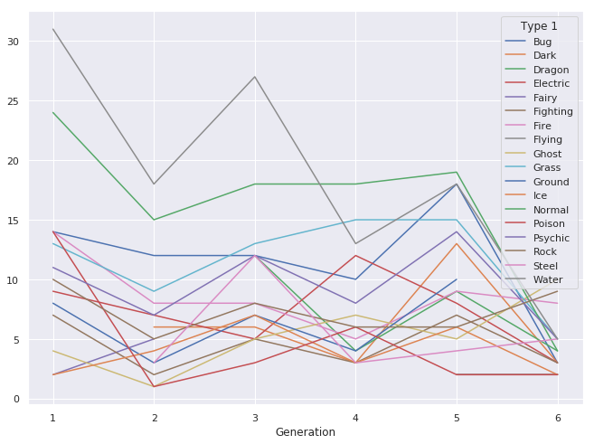

```python
max_type1_per_gen.unstack().plot()
```